# Ass1

Marcos Bernier

2022-02-18

# *** *COMPLETED 15/15***

## Question 1

### Work

Assignments = 15% of grade, Labs = 10% of grade, Projects = 10% of grade, Inclass Quizzes = 10% of grade, Online Chapter Quizzes = 5% of grade, Midterms = 20% of grade, Final = 30% of grade,

### Letter Grades

A = 100-90 B = 89-80 C = 79-70 D = 69-60 F = 59->

## Question 2

### a

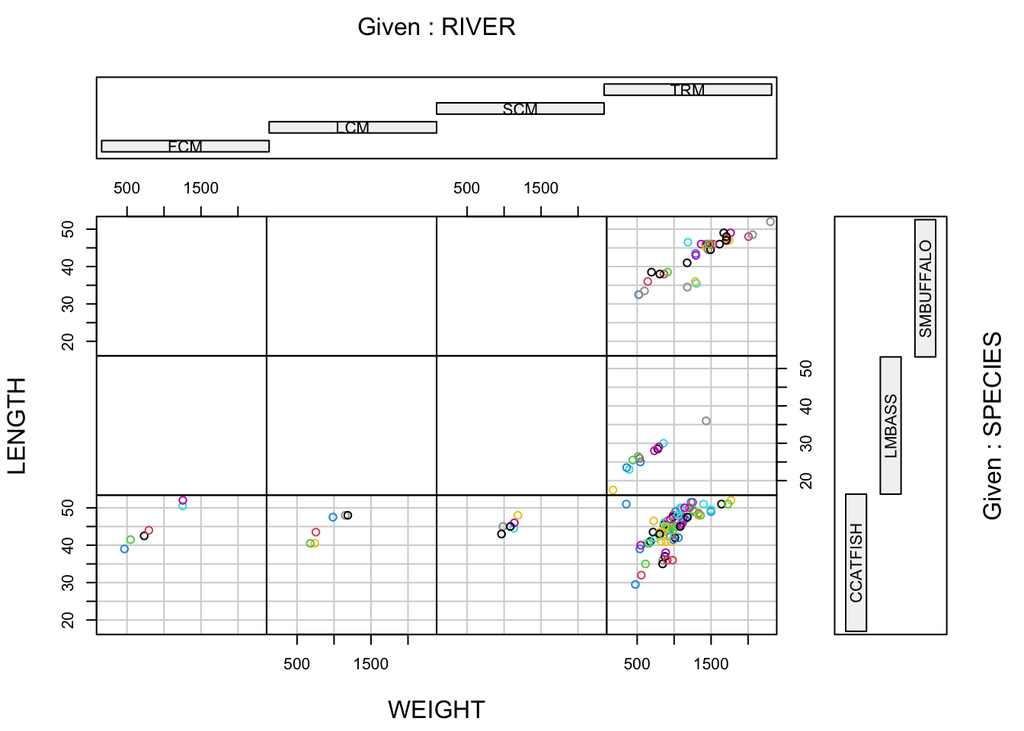

```r
ddt <- read.csv("DDT.csv")
coplot(LENGTH~WEIGHT | RIVER * SPECIES,data = ddt, pch = 1, col = 1:17)
```

### b

They show the data LENGTH v WEIGHT of CCATFISH in the separate three rivers exlcuding TRM, by mile found.

### c

Line A makes a factor m that contains numerical data from MILE in DDT.CSV

### d

Gets a set of all unique values in m, and returns the number of unique values found (unqiue() constructs the set, length() gives the size of the set)

### e

LMBASS and SMBUFFALO aren’t found in 3/4 rivers. Only in TRM.

### f

```r
d <- subset(ddt, SPECIES == "CCATFISH" &  RIVER == "FCM")
mean(d$DDT)
```

```
## [1] 45
```

## Question 3

### a.

quantitative

### b.

quantitative

### c.

qualitative

### d.

quantitative

### e.

qualitative

### f.

quantitative

### g.

qualitative

## Question 4

### a.

Simple (Random) Sampling, Stratified Sampling, Custer Sampling and Systematic Sampling

### b.

Simple random sampling uses a random number to determine the size of a sample. Stratified uses similar characteristics to group samples Cluster samples natural groupings of units, and samples the units within the smaller clusters, or natural groupings. Systematic sampling uses an integer to pick the ith unit for involvement in the sample

## Question 5

```r
sec <- read.csv("MTBE.csv")

sec[sample(1:223,5,replace = FALSE),]
```

```
##       pH SpConduct DissOxy RoadsPct IndPct UrbanPct DevPct WellClass Aquifier
## 219 7.50     264.8    8.45     2.90   4.00    47.50  52.74    Public  Bedrock
## 73  6.06     886.6    1.00     2.64   0.00    11.19  11.19   Private  Bedrock
## 49  7.97     225.0    0.33     2.26   4.41    40.29  55.52   Private  Bedrock
## 50  8.21     153.9    1.83     2.09   0.24    47.55  65.61   Private  Bedrock
## 69  7.12     180.8    4.59     1.76   0.00    28.22  28.22   Private  Bedrock
##        Depth SafeYld Distance MTBE.Detect MTBE.Level HouseDen PopDen
## 219  60.9600      NA   242.05 Below Limit        0.2   130.87  45.36
## 73   92.6592      NA  1728.00 Below Limit        0.2    97.78  37.61
## 49  153.9240      NA  1584.78 Below Limit        0.2   120.10  51.99
## 50   68.5800      NA  2154.46 Below Limit        0.2   204.43  63.70
## 69  174.9552      NA  1849.10 Below Limit        0.2    39.92  12.22
```

### i)

```r
sec2 = na.omit(sec)
```

### ii)

```r
depth = sec2[sec2$Aquifier=="Bedrock",]$Depth
sd(depth)
```

```
## [1] 56.45357
```

## Question 6

```r
data <- read.csv("EARTHQUAKE.csv")
data[sample(nrow(data),30),]
```

```
##      YEAR MONTH DAY HOUR MINUTE MAGNITUDE
## 1915 1994     1  27    0      0       1.4
## 1228 1994     1  22   22     10       1.9
## 2446 1994     2   1   15     51       2.0
## 300  1994     1  18   16      1       2.3
## 800  1994     1  21    0      1       1.5
## 2057 1994     1  27   23     54       2.2
## 1625 1994     1  25    6      8       1.2
## 836  1994     1  21    4     48       2.0
## 67   1994     1  17   14     50       3.8
## 978  1994     1  21   18     12       1.9
## 988  1994     1  21   18     54       3.2
## 2119 1994     1  28   12     11       1.6
## 871  1994     1  21    7     55       1.7
## 1154 1994     1  22   14     26       1.8
```

[output cut: 16 more lines]

### i

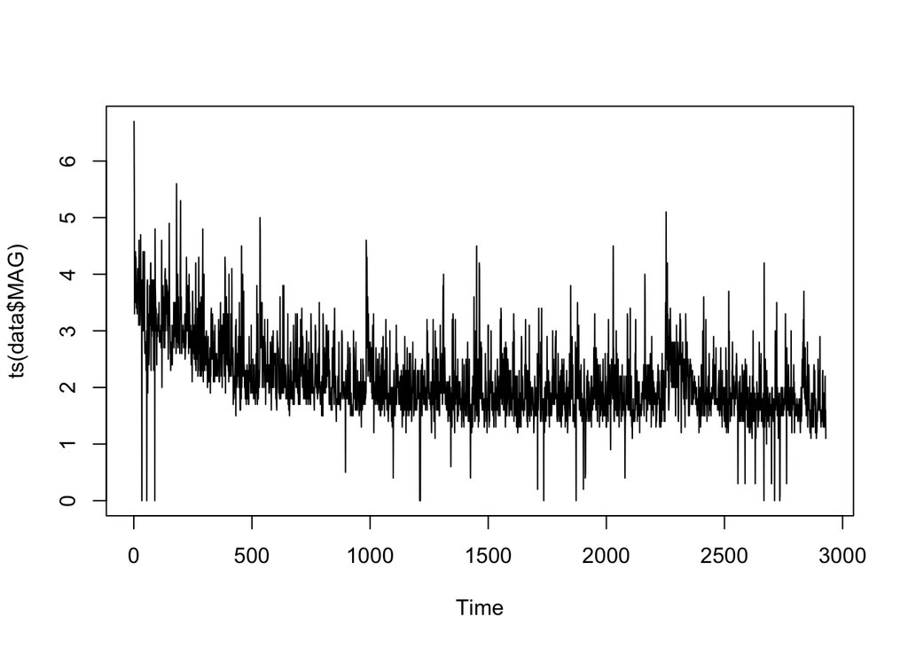

```r
plot(ts(data$MAG))
```

### ii

```r
median(data$MAGNITUDE)
```

```
## [1] 2
```

## Question 7

### a

Designed experiment

### b

The total population of fish in the Tennesse river and its tributaries

### c

River and species

## Question 8

### a

legs only

### d

```r
library(MATH4753BERN0021)
freq = c(15,8,63,20)
RL = c("None","Both","LegsO","WheelsO")
l=rep(RL,freq)
```

### e

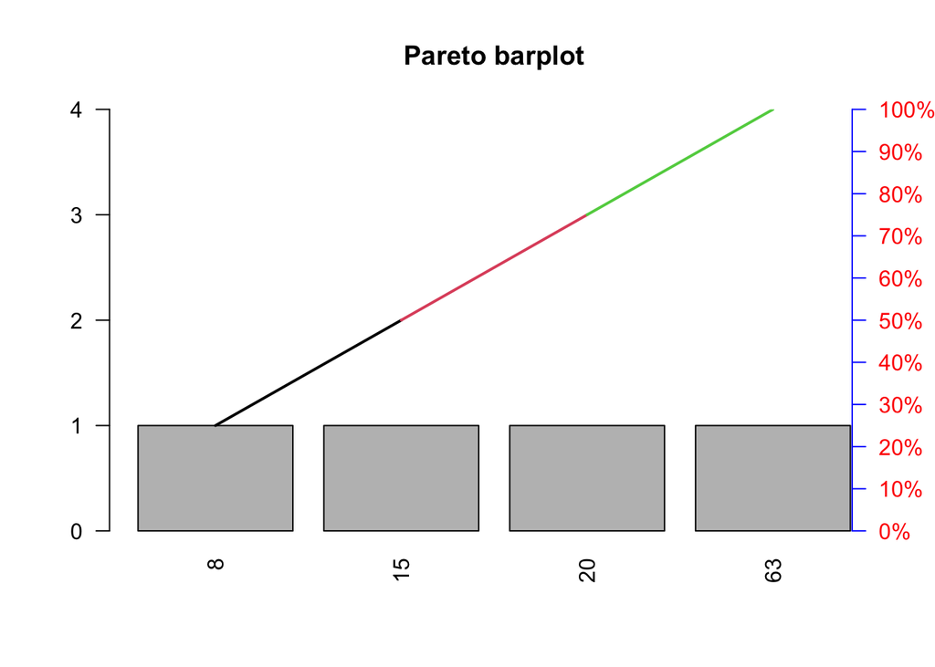

```r
pareto(freq)
```

## Question 9

### a

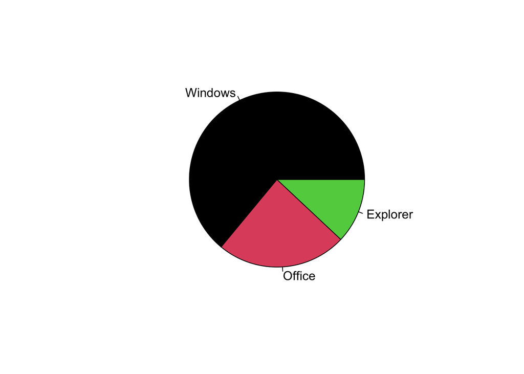

```r
dog <- pie(c(32,12,6),labels = c("Windows","Office","Explorer"),col=1:3)
```

Explorer had the lowest portion.

### b

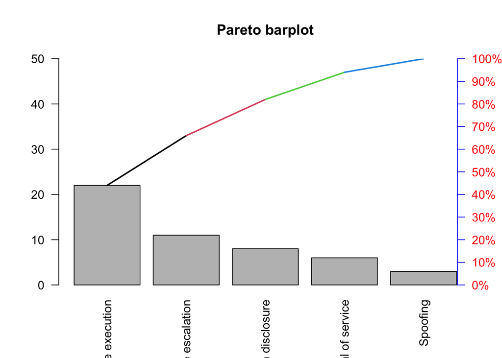

```r
issues = c("Denial of service","Information disclosure","Remote code execution", "Spoofing", "Privledge escalation")
frequencys = c(6,8,22,3,11)
pareto(rep(issues, frequencys))
```

Remote code execution is the most prominent issue

## Question 10

```r
swd = read.csv("SWDEFECTS.csv", header = TRUE)
head(swd)
```

```
##   Mloc Mvg Mevg Mivg   Hn  Hvol Hpgmlen Hdiff Hintell Heffort   Hb Htime Hloc
## 1  1.1 1.4  1.4  1.4  1.3   1.3    1.30  1.30    1.30       1 1.30     1    2
## 2  1.0 1.0  1.0  1.0  1.0   1.0    1.00  1.00    1.00       1 1.00     1    1
## 3 24.0 5.0  1.0  3.0 63.0 309.1    0.11  9.50   32.54    2937 0.10   163    1
## 4 20.0 4.0  4.0  2.0 47.0 215.5    0.06 16.00   13.47    3448 0.07   192    0
## 5 24.0 6.0  6.0  2.0 72.0 346.1    0.06 17.33   19.97    6000 0.12   333    0
## 6 24.0 6.0  6.0  2.0 72.0 346.1    0.06 17.33   19.97    6000 0.12   333    0
##   Hcomm Hblank loc.comm uniOp uniOpnd totOp totOpnd brnchcnt defect
## 1     2      2        2   1.2     1.2   1.2     1.2      1.4  FALSE
## 2     1      1        1   1.0     1.0   1.0     1.0      1.0   TRUE
## 3     0      6        0  15.0    15.0  44.0    19.0      9.0  FALSE
## 4     0      3        0  16.0     8.0  31.0    16.0      7.0  FALSE
## 5     0      3        0  16.0    12.0  46.0    26.0     11.0  FALSE
## 6     0      3        0  16.0    12.0  46.0    26.0     11.0  FALSE
##   predict.vg.10 predict.evg.14.5 predict.ivg.9.2 predict.loc.50
## 1            no               no              no             no
## 2            no               no              no             no
## 3            no               no              no             no
## 4            no               no              no             no
## 5            no               no              no             no
## 6            no               no              no             no
```

```r
library(plotrix)
tab = table(swd$defect)
rtab = tab/sum(tab)
round(rtab,2)
```

```
##
## FALSE  TRUE
##   0.9   0.1
```

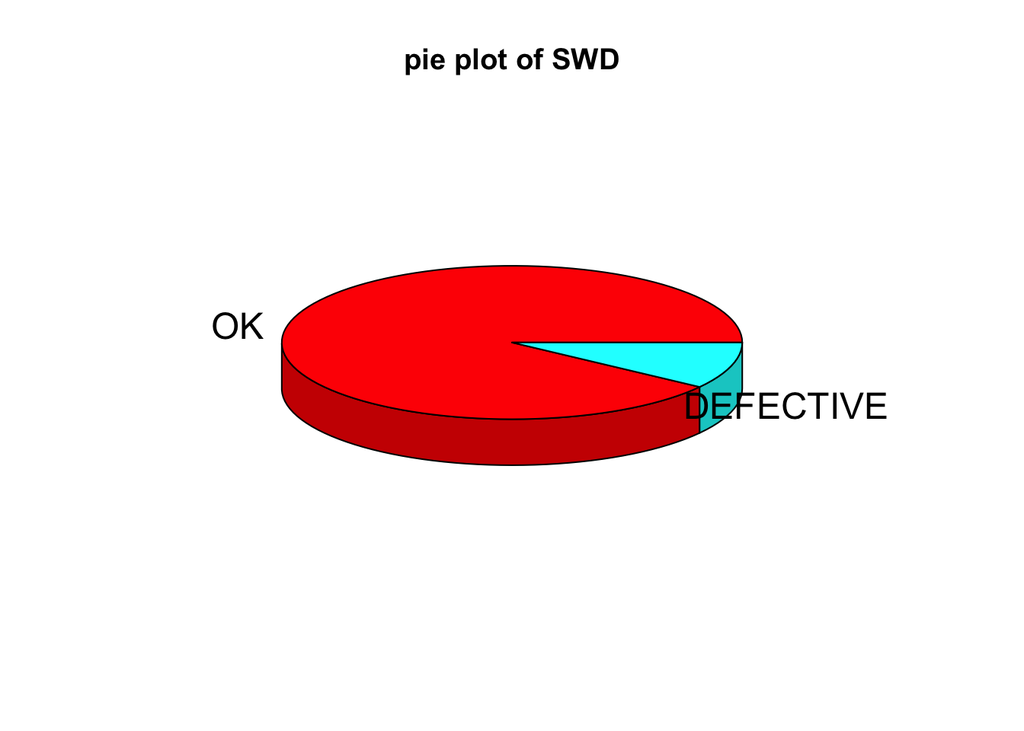

```r
pie3D(rtab, labels = list("OK", "DEFECTIVE"), main = "pie plot of SWD")
```

Most software releases are successful - without defects! The likihood of a defective software release is low.

## Question 11

### a

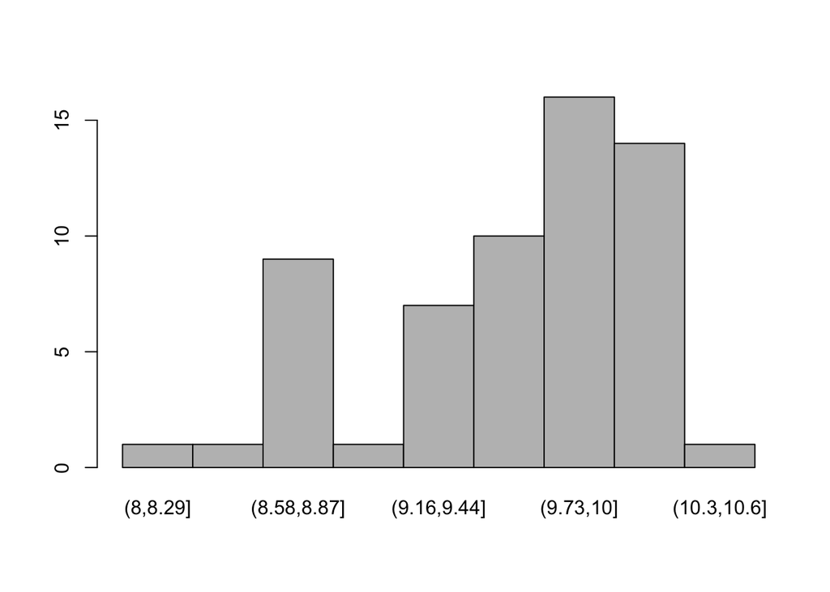

```r
voltage <- read.csv("VOLTAGE.csv")
subvoltage = subset(voltage, LOCATION == "OLD")
tablevoltage = table(cut(sort(voltage$VOLTAGE),breaks = seq(8.0,10.6,by=(2.6/9)),ord = TRUE))
barplot(tablevoltage,space =0)
```

### b

```r
stem(tablevoltage)
```

```
##
##   The decimal point is 1 digit(s) to the right of the |
##
##   0 | 1111
##   0 | 79
##   1 | 04
##   1 | 6
```

### c

```r
newv <- subset(voltage, subset=LOCATION=="NEW")
newv$VOLTAGE->vtn
max(vtn)
```

```
## [1] 10.12
```

```r
min(vtn)
```

```
## [1] 8.51
```

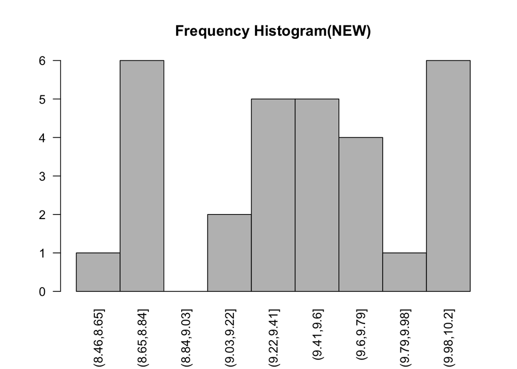

```r
lept<-min(vtn)-0.05
rept<-max(vtn)+0.05
rnge<-rept-lept
inc<-rnge/9
seq(lept,rept,by=inc)->cl

cvtn <- cut(vtn,breaks = cl)
new.tab =table(cvtn)
barplot(new.tab,space=0,main="Frequency Histogram(NEW)",las=2)
```

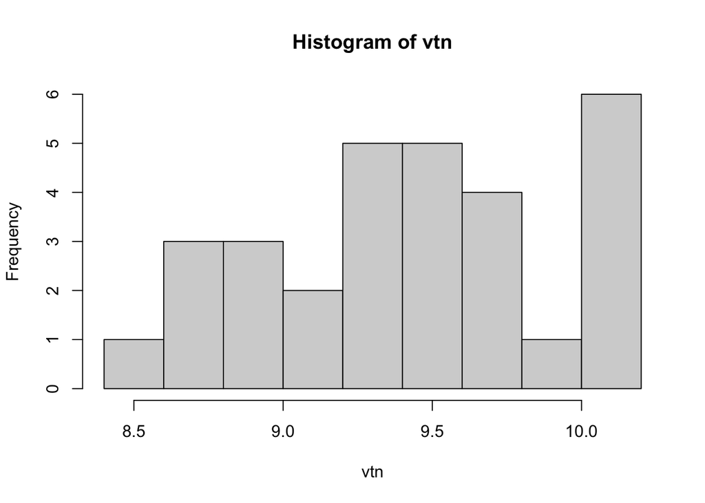

```r
   hist(vtn,nclass=10)
```

### d

Old is better!

### e

```r
#Old

mode <- function(v)
{
  newNum <- unique(v)
  newNum[which.max(tabulate(match(v,newNum)))]
}

mean((subset(voltage, LOCATION=="OLD"))$VOLTAGE)
```

```
## [1] 9.803667
```

```r
median((subset(voltage, LOCATION=="OLD"))$VOLTAGE)
```

```
## [1] 9.975
```

```r
mode((subset(voltage, LOCATION=="OLD"))$VOLTAGE)
```

```
## [1] 9.98
```

```r
#NEw
mean((subset(voltage, LOCATION=="NEW"))$VOLTAGE)
```

```
## [1] 9.422333
```

```r
median((subset(voltage, LOCATION=="NEW"))$VOLTAGE)
```

```
## [1] 9.455
```

```r
mode((subset(voltage, LOCATION=="NEW"))$VOLTAGE)
```

```
## [1] 8.82
```

OLD is better fit using the median. NEW is better fit using the mean! They are respectively closer to their modes.

### f

```r
(10 - mean(subset(voltage, LOCATION=="OLD")$VOLTAGE))/(sd(subset(voltage, LOCATION=="OLD")$VOLTAGE))
```

```
## [1] 0.3629649
```

### g

```r
(10 - mean(subset(voltage, LOCATION=="NEW")$VOLTAGE))/(sd(subset(voltage, LOCATION=="NEW")$VOLTAGE))
```

```
## [1] 1.206298
```

### h

Old, the zscore is closer to 0 which means it derives less from the mean

### i

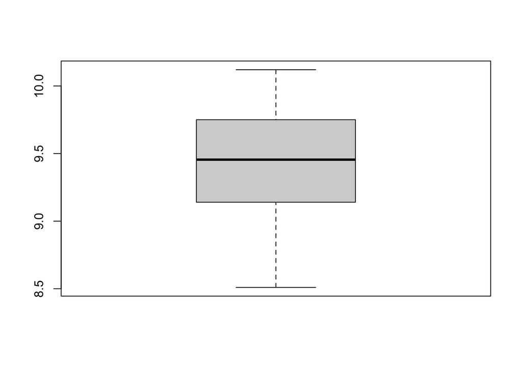

```r
boxplot((subset(voltage, LOCATION=="NEW"))$VOLTAGE)
```

### j

```r
old = subset(voltage, LOCATION=="OLD")

(old$VOLTAGE-mean(old$VOLTAGE))/(sd(old$VOLTAGE))
```

```
##  [1]  0.325990556  0.843631515  0.455400796  0.899093047  0.418426442
##  [6] -3.242034625  1.379759651  0.843631515  0.307503379  0.122631608
## [11]  0.584811036  0.455400796 -0.006778632  0.640272567  0.362964911
## [16]  0.122631608 -0.468958059  0.270529025 -0.191650403 -2.003393759
## [21]  0.067170077  0.640272567  0.399939265 -0.006778632 -0.136188871
## [26]  0.381452088  0.325990556 -2.003393759 -1.855496342  0.067170077
```

1 outlier!

### k

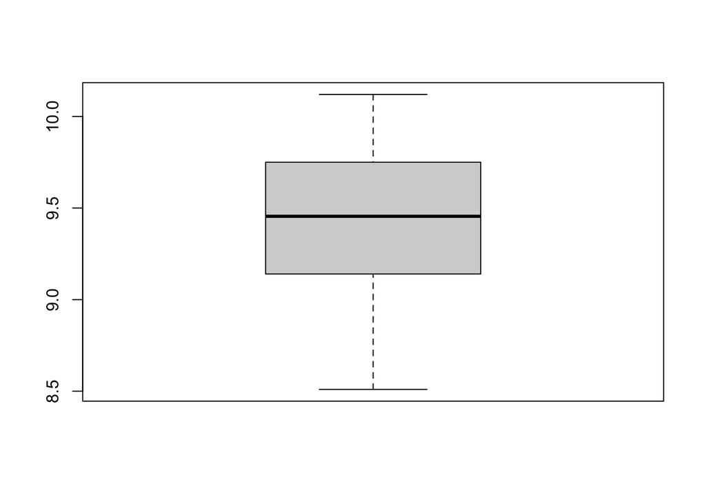

```r
news = subset(voltage, LOCATION=="NEW")
boxplot(news$VOLTAGE)
```

### l

```r
(news$VOLTAGE-mean(news$VOLTAGE))/(sd(news$VOLTAGE))
```

```
##  [1] -0.48516415  0.43365462  1.41512012  0.57983033  1.39423788  0.37100788
##  [7]  1.31070890  1.45688461  0.14130319 -0.10928375  1.22717992 -1.25780721
## [13]  0.01600972  1.26894441  0.89306400 -0.31810620 -1.23692497 -0.06751926
## [19]  0.12042095  0.45453686 -1.25780721 -1.61280538 -1.90515680 -0.58957538
## [25]  0.68424156 -1.34133619 -0.15104824  0.24571441 -0.13016599 -1.55015864
```

No outliers? I think. No Z>3 or <-3

### m

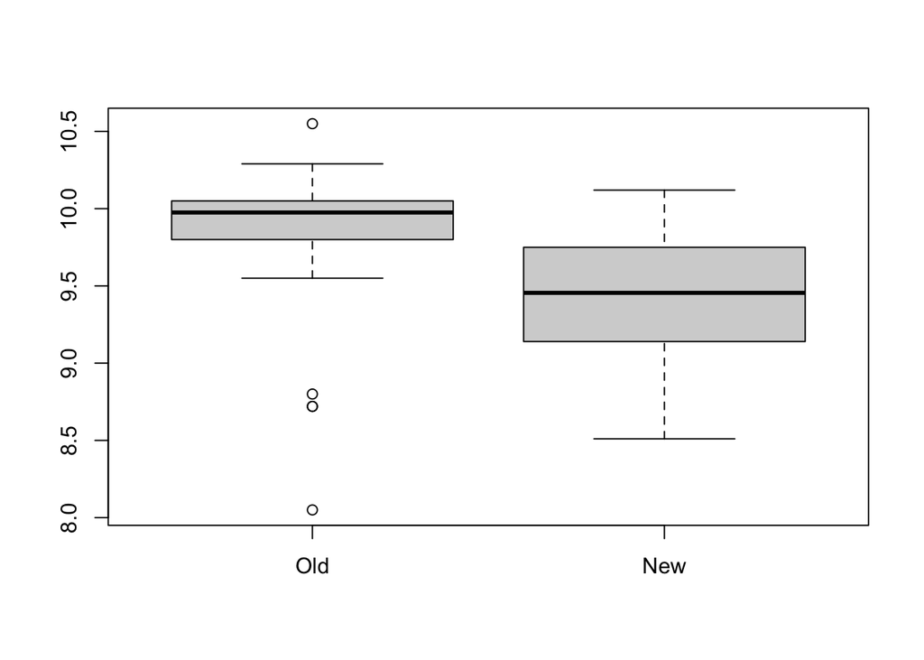

```r
boxplot(old$VOLTAGE,news$VOLTAGE,names = c("Old","New"), horizontal = FALSE)
```

## Question 12

```r
rough = read.csv("ROUGHPIPE.csv")

mean = mean(rough$ROUGH)

int1 = mean - (2*sd(rough$ROUGH))
int2 = mean + (2*sd(rough$ROUGH))
int1
```

```
## [1] 0.8331772
```

```r
int2
```

```
## [1] 2.928823
```

## Question 13

### a

```r
gobiants <- read.csv("GOBIANTS.csv")

mean(gobiants$AntSpecies)
```

```
## [1] 12.81818
```

```r
median(gobiants$AntSpecies)
```

```
## [1] 5
```

```r
#mode(gobiants$AntSpecies)
```

There is no mode function for R. Looking at the data, the mode is 4 or 5. They appear = times.

### b

We should use the median. Data is skewed in this dataset.

### c

```r
mean(gobiants$PlantCov[gobiants$Region=="Dry Steppe"])
```

```
## [1] 40.4
```

```r
median(gobiants$PlantCov[gobiants$Region=="Dry Steppe"])
```

```
## [1] 40
```

Mode is 40

### d

```r
mean(gobiants$PlantCov[gobiants$Region== "Gobi Desert"])
```

```
## [1] 28
```

```r
median(gobiants$PlantCov[gobiants$Region== "Gobi Desert"])
```

```
## [1] 26
```

Mode is 30

### e

Yes

## Question 14

### a

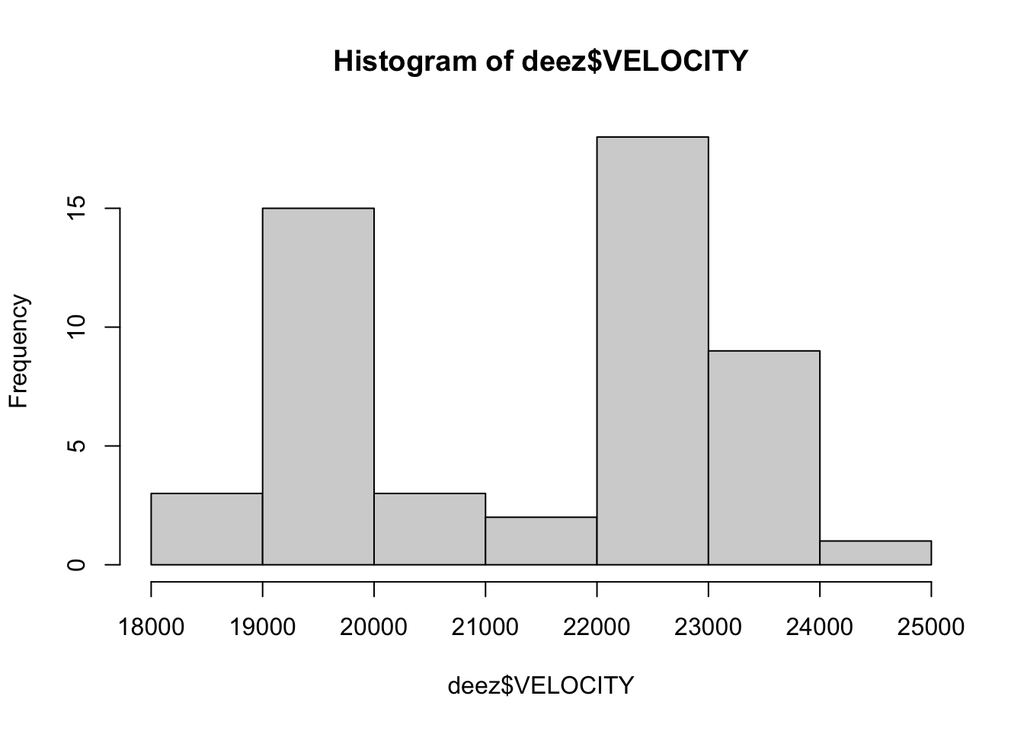

```r
deez <- read.csv("GALAXY2.csv")

hist(deez$VELOCITY)
```

### b

The data seemingly has two natural clusters that split down the middle of the histogram. So yes! The double cluster theory seems to valid. @ 21000

### c

```r
sd(deez[deez$VELOCITY < 21000,])
```

```
## [1] 532.2868
```

```r
mean(deez[deez$VELOCITY < 21000,])
```

```
## [1] 19462.24
```

A1775A

```r
sd(deez[deez$VELOCITY > 21000,])
```

```
## [1] 560.9767
```

```r
mean(deez[deez$VELOCITY > 21000,])
```

```
## [1] 22838.47
```

A1775B

### d

20k falls within 2 standard deviations of the mean of A1775A, so it most likely belongs to A1775A cluster.

## Question 15

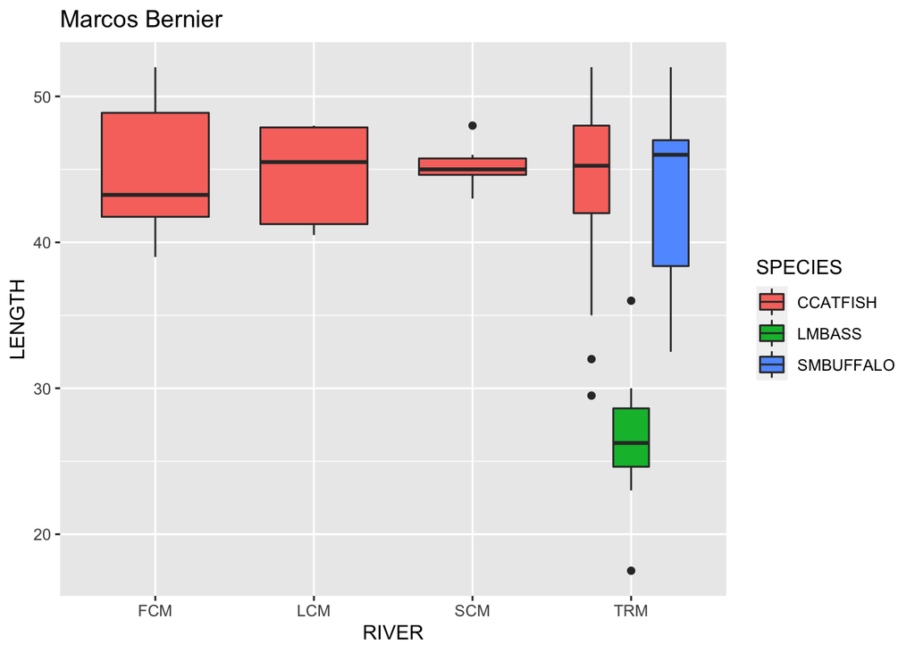

```r
library(ggplot2)
rivers <- read.csv("DDT.csv")
p = ggplot(rivers, aes(x=RIVER, y = LENGTH, fill = SPECIES))
p = p + geom_boxplot()
p = p+ggtitle(label = "Marcos Bernier")
p
```